Chinmay Raut  
93345289

# Replicating the PCA of a published Study

## about the assignment

For my final project wrapping up 1 quarter of independent study under Edwin Solares. I had to recreate the PCA portion of a paper that was analyzing genomic data.

The paper whose PCA study I chose to replicate was:

**High-Density SNP Genotyping of Tomato (Solanum lycopersicum L.) Reveals Patterns of Genetic Variation Due to Breeding**

by: Sung-Chur Sim, Allen Van Deynze, Kevin Stoffel, et al.

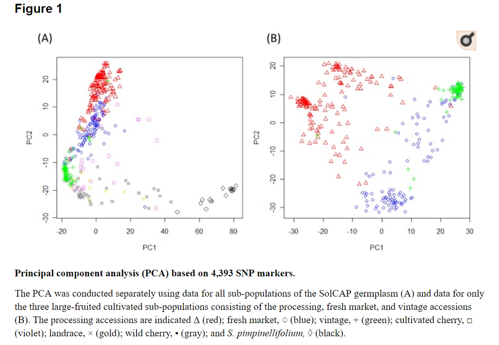

```python
from IPython.display import Image
Image("./imgs/Figure1.png")
```

## about the paper

The study took a collection of 426 tomatoes (410 inbred & 16 hybrids) and had each of their SNP's genotyped. This meant that they sequenced the tomato's genome, and then identified which nucleotide was present at each of the 7,000+ Single Nucleotide Polymorphism sites further marking which nucleotide came from which parent. Then on this data they performed Principal Component analysis using the SNP sites to verify that the tomatoes could be segregated into their corresponding subpopulations (originally defined from their phenotypes) through this SNP data of each tomato. Then using the variances and contributions they had from each of the SNP sites in their PCA they were able to determine which SNP's were the most influential in segregating the tomatoes into their subpopulation which in turn highlighted the chromosomes and sites of interest as the contributors of the phenotypic differences between the plants. These phenotypic differences were deemed important as these tomatoes have been bred by people from different cultures to achieve these certain traits and understanding the genetic background and function could prove useful while engineering new behaviors in such plants.

The study found that in even inbred tomatoes (tomatoes which when mating with themselves produce perfect clones due to histories of inbreeding) there exists high levels of genetic diversity among the SNP's. They also learned that chromosomes 2, 4, 5, 6, and 11 in particular host the SNP's which explained much of the differences observed in the subpopulations from the PCA's. Through the use of F-tests and studying the Minor Allele frequency patterns they confirmed these regions as influential.

## performing the pca

This dataset & pca analysis were not very conventional for me, and there was a lot to learn regarding snp data and performing analysis on it.

```python
# import all the useful libraries

import pandas as pd
from sklearn.preprocessing import StandardScaler
from sklearn.decomposition import PCA
import numpy as np
import seaborn as sns
from scipy import stats
import matplotlib.pyplot as plt
from collections import Counter
```

This 1st table I imported contained a lot of data regarding each subject (tomato) which is represented by the name format "SCT_####"

I really only cared about which subject corresponded to which tomato subpopulation based off of the phenotypic analysis with this table.

```python
filename = "./data/TableS1_specimen_data.csv"
specimen_df = pd.read_csv(filename)

spec_to_type = {}

for i,row in specimen_df.iterrows():
    spec_to_type[row[0]] = row[5]

tmp = Counter(spec_to_type.values())

for k in tmp:
    print(k,tmp[k])

type_to_col = {'Wild Cherry':'gray', 'Processing':'red', 'Fresh market':'blue', 'Cultivated Cherry':'violet', 'Latin American Cultivar':'gold', 'Vintage':'green', 'Wild':'black'}

type_to_marker = {'Wild Cherry':'.', 'Processing':'^', 'Fresh market':'o', 'Cultivated Cherry':'s', 'Latin American Cultivar':'x', 'Vintage':'+', 'Wild':'d'}
```

```
('Wild Cherry', 43)
('Fresh market/Processing', 1)
('Processing', 141)
('Vintage/Processing', 2)
('Fresh market', 109)
('Cultivated Cherry', 27)
('Latin American Cultivar', 12)
('Hybrid', 16)
('Vintage', 59)
('Wild', 16)
```

This 2nd table contained all the SNP data. The sequencing was done by illumina and this is a pretty standard format of theirs.

The SNP forms the rows & the subject form the column with each cell in the intersection corresponding to a 2 nucleotide pair which stated which nucleotide the subject received from which parent.

This dataset was adequetly sized with 7,000+ potential SNP sites of interest and 400+ subjects in the study -> about 12 MB of data.

```python
file_name = "./data/TableS2_snp_data.csv"
df = pd.read_csv(file_name)
print(df.shape)
df.head()
```

```
(7720, 433)
```

|  | SNP markers | Missing data | Polymorphism | Chromosome | Position (Mbp) | Chromosome.1 | Position (cM) | SCT_0001 | SCT_0002 | SCT_0003 | ... | SCT_0502 | SCT_0503 | SCT_0504 | SCT_0505 | SCT_0527 | SCT_0534 | SCT_0535 | SCT_0536 | SCT_0537 | SCT_0538 |
| --- | --- | --- | --- | --- | --- | --- | --- | --- | --- | --- | --- | --- | --- | --- | --- | --- | --- | --- | --- | --- | --- |
| 0 | solcap_snp_sl_15058 | < 10% | POLY | 1 | 0.0454 | 1 | 0 | AA | AA | AA | ... | AG | AA | AA | AG | GG | GG | AA | AA | AA | AA |
| 1 | solcap_snp_sl_60635 | < 10% | POLY | 1 | 0.0471 | 1 | 0 | CC | CC | CC | ... | CC | CC | CC | CC | CC | TT | CC | CC | CC | CC |
| 2 | solcap_snp_sl_60604 | < 10% | POLY | 1 | 0.1921 | 1 | 0.2712 | CC | CC | CC | ... | CC | CC | CC | CC | CC | CC | CC | CC | CC | CC |
| 3 | solcap_snp_sl_15056 | < 10% | POLY | 1 | 0.26 | Unknown | Unknown | TT | TT | TT | ... | GG | TT | TT | TG | TG | TT | TT | TT | TT | TT |
| 4 | solcap_snp_sl_15055 | < 10% | POLY | 1 | 0.2996 | Unknown | Unknown | CC | CC | CC | ... | TT | CC | CC | TC | TC | -- | CC | CC | CC | CC |

5 rows × 433 columns

```python
df.columns[7:]
```

```
Index([u'SCT_0001', u'SCT_0002', u'SCT_0003', u'SCT_0004', u'SCT_0005',
       u'SCT_0006', u'SCT_0007', u'SCT_0008', u'SCT_0009', u'SCT_0010',
       ...
       u'SCT_0502', u'SCT_0503', u'SCT_0504', u'SCT_0505', u'SCT_0527',
       u'SCT_0534', u'SCT_0535', u'SCT_0536', u'SCT_0537', u'SCT_0538'],
      dtype='object', length=426)
```

Here I begin the processing for the 1st PCA graph. I used a table that they referenced from a different paper they published around that time that they said that they used to determine which SNP's to include for their PCA. Note that this is how they got 4,000+ SNPs instead of 7,000+ SNPs in the title of figure 1's PCA's.

I seperate the nucleotides received from each parent as they will need to be mapped seperately during the PCA as there is a difference whether a nucleotide was obtained from the father or the mother. For most of the specimens due to inbreding they have the same nucleotide from both parents but there were instances in which I witnessed a difference between mother & father supplied nucleotides so I wanted to make sure. The mapping of the nucleotides was a simple numeric one. One thing to note is that the mapping will give the nucleotides an order even if it's meaningless for now.

```python
# Figure A filtering

imp_snp_fname = "./data/TableS4_(Moneymaker).csv"
imp_snp_df = pd.read_csv(imp_snp_fname)
imp_snps = set(imp_snp_df["SNP Marker"])

print(len(imp_snps))
```

```
4492
```

```python
nucleotide_mappings = {"-":0,"A":1,"G":2,"C":3,"T":4}


filtered_df = []
for i,row in df.iterrows():
    if row["Missing data"] == "< 10%" and row[0] in imp_snps:
        cpy_row1 = list(row)
        cpy_row2 = list(row)
        cpy_row1[0]+="p1"
        cpy_row2[0]+="p2"
        for j in range(7,len(row)):
            cpy_row1[j] = nucleotide_mappings[row[j][0]]
            cpy_row2[j] = nucleotide_mappings[row[j][1]]
            #print row[j],cpy_row1[j],cpy_row2[j]
        filtered_df.append(cpy_row1)
        filtered_df.append(cpy_row2)

filtered_df = pd.DataFrame(filtered_df,columns=df.columns)
print(filtered_df.shape)
filtered_df.tail()
```

```
(8852, 433)
```

|  | SNP markers | Missing data | Polymorphism | Chromosome | Position (Mbp) | Chromosome.1 | Position (cM) | SCT_0001 | SCT_0002 | SCT_0003 | ... | SCT_0502 | SCT_0503 | SCT_0504 | SCT_0505 | SCT_0527 | SCT_0534 | SCT_0535 | SCT_0536 | SCT_0537 | SCT_0538 |
| --- | --- | --- | --- | --- | --- | --- | --- | --- | --- | --- | --- | --- | --- | --- | --- | --- | --- | --- | --- | --- | --- |
| 8847 | solcap_snp_sl_12660p2 | < 10% | Undetermined | 12 | 2.1557 | 12 | 16.3168 | 2 | 2 | 2 | ... | 0 | 2 | 0 | 0 | 0 | 2 | 2 | 2 | 2 | 2 |
| 8848 | solcap_snp_sl_41233p1 | < 10% | Undetermined | 12 | 3.4192 | 12 | 26.2564 | 2 | 2 | 2 | ... | 2 | 2 | 2 | 2 | 2 | 2 | 2 | 2 | 2 | 2 |
| 8849 | solcap_snp_sl_41233p2 | < 10% | Undetermined | 12 | 3.4192 | 12 | 26.2564 | 2 | 2 | 2 | ... | 2 | 2 | 2 | 2 | 2 | 2 | 2 | 2 | 2 | 2 |
| 8850 | solcap_snp_sl_10957p1 | < 10% | Undetermined | Unknown | Unknown | 11 | 50.8766 | 4 | 4 | 4 | ... | 4 | 4 | 4 | 4 | 4 | 4 | 4 | 4 | 4 | 4 |
| 8851 | solcap_snp_sl_10957p2 | < 10% | Undetermined | Unknown | Unknown | 11 | 50.8766 | 4 | 2 | 4 | ... | 4 | 2 | 2 | 4 | 2 | 4 | 4 | 2 | 2 | 2 |

5 rows × 433 columns

Here I transpose the matrix to a more familiar format for working with SNP data with rows being subjects and columns being the numeric nucleotide mappings.

```python
features = df.columns[7:]
x = filtered_df.loc[:,features].values
x = x.T

transposed_data = pd.DataFrame(x,columns = list(filtered_df['SNP markers']))
transposed_data['Specimen ID'] = filtered_df.columns[7:]

print(transposed_data.shape)
transposed_data.tail()
```

```
(426, 8853)
```

|  | solcap_snp_sl_15058p1 | solcap_snp_sl_15058p2 | solcap_snp_sl_60635p1 | solcap_snp_sl_60635p2 | solcap_snp_sl_60604p1 | solcap_snp_sl_60604p2 | solcap_snp_sl_15054p1 | solcap_snp_sl_15054p2 | solcap_snp_sl_15052p1 | solcap_snp_sl_15052p2 | ... | solcap_snp_sl_10960p2 | SL1_00sc6004_1941124p1 | SL1_00sc6004_1941124p2 | solcap_snp_sl_12660p1 | solcap_snp_sl_12660p2 | solcap_snp_sl_41233p1 | solcap_snp_sl_41233p2 | solcap_snp_sl_10957p1 | solcap_snp_sl_10957p2 | Specimen ID |
| --- | --- | --- | --- | --- | --- | --- | --- | --- | --- | --- | --- | --- | --- | --- | --- | --- | --- | --- | --- | --- | --- |
| 421 | 2 | 2 | 4 | 4 | 3 | 3 | 3 | 3 | 3 | 3 | ... | 2 | 4 | 3 | 2 | 2 | 2 | 2 | 4 | 4 | SCT_0534 |
| 422 | 1 | 1 | 3 | 3 | 3 | 3 | 3 | 3 | 3 | 3 | ... | 2 | 4 | 3 | 2 | 2 | 2 | 2 | 4 | 4 | SCT_0535 |
| 423 | 1 | 1 | 3 | 3 | 3 | 3 | 3 | 3 | 3 | 3 | ... | 2 | 4 | 3 | 1 | 2 | 2 | 2 | 4 | 2 | SCT_0536 |
| 424 | 1 | 1 | 3 | 3 | 3 | 3 | 3 | 3 | 3 | 3 | ... | 2 | 4 | 3 | 1 | 2 | 2 | 2 | 4 | 2 | SCT_0537 |
| 425 | 1 | 1 | 3 | 3 | 3 | 3 | 3 | 3 | 3 | 3 | ... | 2 | 4 | 3 | 1 | 2 | 2 | 2 | 4 | 2 | SCT_0538 |

5 rows × 8853 columns

Here I filter out the subjects which are not included in the PCA due to lack of type representation.

```python
fig_a_filt_df = []
types = []
for i,row in transposed_data.iterrows():
    if spec_to_type[row[-1]] in type_to_col:
        fig_a_filt_df.append(list(row))
        types.append(spec_to_type[row[-1]])

fig_a_filt_df = pd.DataFrame(fig_a_filt_df,columns=transposed_data.columns)
fig_a_filt_df['Specimen Type'] = types

print(fig_a_filt_df.shape)
fig_a_filt_df.tail()
```

```
(407, 8854)
```

|  | solcap_snp_sl_15058p1 | solcap_snp_sl_15058p2 | solcap_snp_sl_60635p1 | solcap_snp_sl_60635p2 | solcap_snp_sl_60604p1 | solcap_snp_sl_60604p2 | solcap_snp_sl_15054p1 | solcap_snp_sl_15054p2 | solcap_snp_sl_15052p1 | solcap_snp_sl_15052p2 | ... | SL1_00sc6004_1941124p1 | SL1_00sc6004_1941124p2 | solcap_snp_sl_12660p1 | solcap_snp_sl_12660p2 | solcap_snp_sl_41233p1 | solcap_snp_sl_41233p2 | solcap_snp_sl_10957p1 | solcap_snp_sl_10957p2 | Specimen ID | Specimen Type |
| --- | --- | --- | --- | --- | --- | --- | --- | --- | --- | --- | --- | --- | --- | --- | --- | --- | --- | --- | --- | --- | --- |
| 402 | 2 | 2 | 4 | 4 | 1 | 1 | 3 | 3 | 3 | 3 | ... | 4 | 3 | 2 | 2 | 2 | 2 | 4 | 2 | SCT_0437 | Wild |
| 403 | 2 | 2 | 3 | 3 | 1 | 1 | 4 | 4 | 1 | 1 | ... | 4 | 3 | 2 | 2 | 2 | 2 | 4 | 2 | SCT_0438 | Wild |
| 404 | 2 | 2 | 4 | 4 | 1 | 1 | 4 | 4 | 1 | 1 | ... | 4 | 3 | 2 | 2 | 1 | 2 | 4 | 2 | SCT_0472 | Wild |
| 405 | 2 | 2 | 3 | 3 | 3 | 3 | 4 | 4 | 1 | 1 | ... | 4 | 4 | 2 | 2 | 2 | 2 | 4 | 2 | SCT_0474 | Wild |
| 406 | 2 | 2 | 3 | 3 | 3 | 3 | 3 | 3 | 3 | 3 | ... | 4 | 4 | 2 | 2 | 2 | 2 | 4 | 4 | SCT_0494 | Wild |

5 rows × 8854 columns

Now I begin the PCA, finding the major 2 principal components

```python
features = fig_a_filt_df.columns[:-2]
x_a = fig_a_filt_df.loc[:,features].values
print x_a.shape

x_a = StandardScaler().fit_transform(x_a)
```

```
(407, 8852)
```

```python
pca_a = PCA(n_components=2)
principalComponents_a = pca_a.fit_transform(x_a)
principalDf_a = pd.DataFrame(data = principalComponents_a
             , columns = ['principal component 1', 'principal component 2'])
```

```python
finalDf_a = pd.concat([principalDf_a, fig_a_filt_df['Specimen ID'], fig_a_filt_df['Specimen Type']], axis = 1)
finalDf_a.tail()
```

|  | principal component 1 | principal component 2 | Specimen ID | Specimen Type |
| --- | --- | --- | --- | --- |
| 402 | 200.715989 | -12.841809 | SCT_0437 | Wild |
| 403 | 178.121284 | 5.039343 | SCT_0438 | Wild |
| 404 | 239.103437 | -17.986599 | SCT_0472 | Wild |
| 405 | 100.371330 | 28.916979 | SCT_0474 | Wild |
| 406 | -11.423912 | 37.093917 | SCT_0494 | Wild |

Here I plot and report the results of the PCA on the dataset that I filtered according to the what I knew about the study producing my own version of Figure 1A:

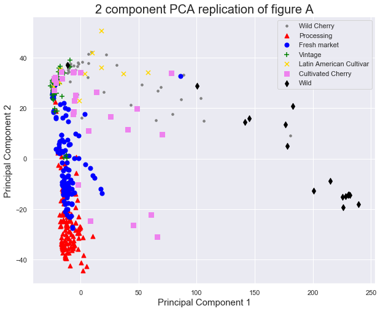

```python
sns.set()

f, ax = plt.subplots(1, 1, figsize=(10, 8))

ax.set_xlabel('Principal Component 1', fontsize = 15)
ax.set_ylabel('Principal Component 2', fontsize = 15)
ax.set_title('2 component PCA replication of figure A', fontsize = 20)
for t in type_to_col:
    tmp_df = finalDf_a[finalDf_a['Specimen Type']==t]
    if tmp_df.shape[0] > 0:
        ax.scatter(tmp_df['principal component 1']
               , tmp_df['principal component 2']
               , s = 50,c=type_to_col[t],marker=type_to_marker[t],label=t)
ax.legend()

plt.show()
```

```python
for i,var in enumerate(pca_a.explained_variance_):
    print("Variance in Principal Component {}: {}".format(i+1,var))
```

```
Variance in Principal Component 1: 2023.99203327
Variance in Principal Component 2: 676.366122902
```

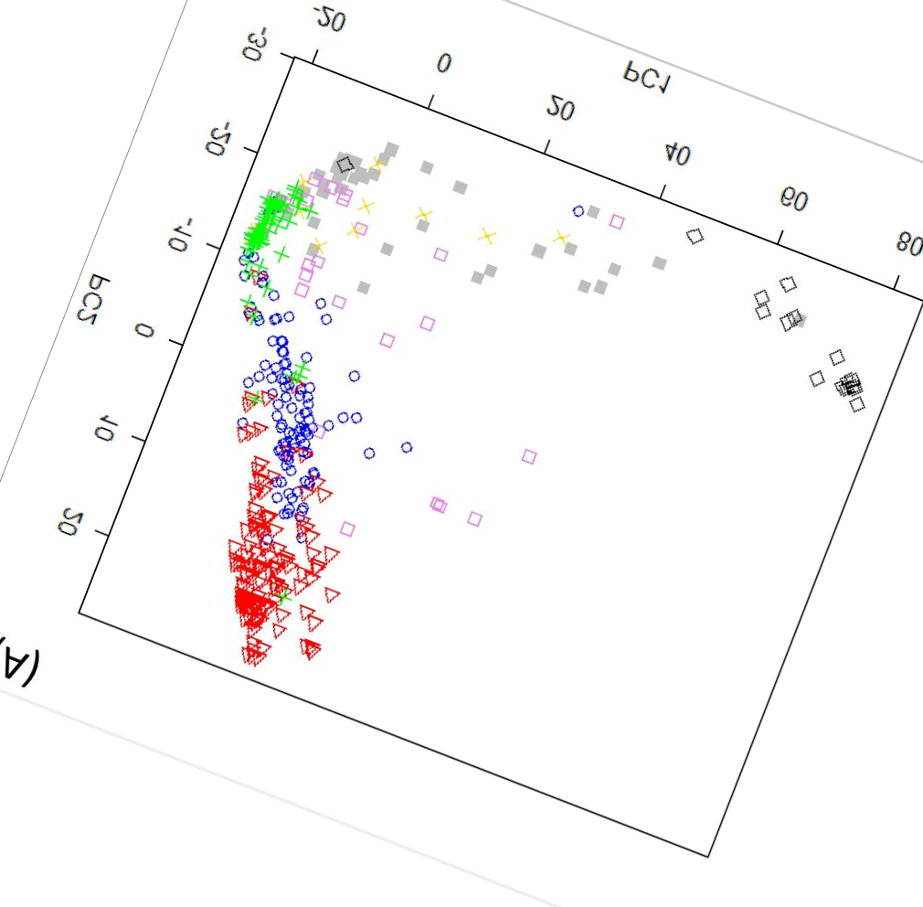

```python
Image("./imgs/Figure1A_rot.png")
```

The figure looks a bit different (flipped & tilted), but we can clearly see the seperation of the Wild tomatoes compared to the inbred ones just like in the figure from the paper. Also the Processing, Fresh Market, and Vinatge/Latin American Cultivar tomatoes look pretty seperated just like the one from the paper, so I'm pretty pleased with this recreation.

I think these changes might have been caused to some preprocessing of data that was not mentioned in the paper or a difference in software as the paper used R packages whereas I'm using python 2.

Here is where I begin the work for the processing of the data for Figure 1B. The 3 tables that I load in are tables which correspond to the important SNP's identified in diferentiating between 2 specified subspecies of tomato. I basically use these tables to figure out which SNP's to include during my PCA analysis.

Contrary to the title of the figure from the paper. I believe that these SNP's are used instead of the 4,000+ that are mentioned because using those SNP's resulted in a far different PCA result which mimiced the distribution and figure of the red, green, and blue points from my version of Figure 1A.

```python
# Figure B filtering

imp_snp1_fname = "./data/snp_selected_bw_Proc_FreshM.csv"
imp_snp2_fname = "./data/snp_selected_bw_Proc_Vin.csv"
imp_snp3_fname = "./data/snp_selected_bw_FreshM_Vin.csv"

imp_snp1_df = pd.read_csv(imp_snp1_fname)
imp_snp2_df = pd.read_csv(imp_snp2_fname)
imp_snp3_df = pd.read_csv(imp_snp3_fname)

print("shape of df1: ", imp_snp1_df.shape)
print("shape of df2: ", imp_snp2_df.shape)
print("shape of df3: ", imp_snp3_df.shape)
```

```
('shape of df1: ', (339, 8))
('shape of df2: ', (128, 8))
('shape of df3: ', (209, 8))
```

```python
imp_snps = set(imp_snp1_df['Marker'])|set(imp_snp2_df['Marker'])|set(imp_snp3_df['Marker'])
print(len(imp_snps))
```

```
564
```

Here I do the filtering just like above for Figure 1A, but instead of just filtering for type of tomato I also filter out the SNP's that weren't identified as significant by the tables.

```python
nucleotide_mappings = {"-":0,"A":1,"G":2,"C":3,"T":4}


cnt = 0
filtered_df = []
for i,row in df.iterrows():
    cnt+=1
    #if cnt == 150:
    #    break
    if row[0] in imp_snps:
        #print "match"
        cpy_row1 = list(row)
        cpy_row2 = list(row)
        cpy_row1[0]+="p1"
        cpy_row2[0]+="p2"
        for j in range(7,len(row)):
            cpy_row1[j] = nucleotide_mappings[row[j][0]]
            cpy_row2[j] = nucleotide_mappings[row[j][1]]
            #print row[j],cpy_row1[j],cpy_row2[j]
        filtered_df.append(cpy_row1)
        filtered_df.append(cpy_row2)

filtered_df = pd.DataFrame(filtered_df,columns=df.columns)
print(filtered_df.shape)
filtered_df.tail()
```

```
(1128, 433)
```

|  | SNP markers | Missing data | Polymorphism | Chromosome | Position (Mbp) | Chromosome.1 | Position (cM) | SCT_0001 | SCT_0002 | SCT_0003 | ... | SCT_0502 | SCT_0503 | SCT_0504 | SCT_0505 | SCT_0527 | SCT_0534 | SCT_0535 | SCT_0536 | SCT_0537 | SCT_0538 |
| --- | --- | --- | --- | --- | --- | --- | --- | --- | --- | --- | --- | --- | --- | --- | --- | --- | --- | --- | --- | --- | --- |
| 1123 | solcap_snp_sl_40829p2 | < 10% | POLY | Unknown | Unknown | 5 | 48.1349 | 3 | 0 | 4 | ... | 3 | 3 | 3 | 3 | 3 | 4 | 4 | 4 | 4 | 3 |
| 1124 | solcap_snp_sl_58718p1 | < 10% | POLY | Unknown | Unknown | 4 | 55.8442 | 3 | 3 | 3 | ... | 3 | 3 | 3 | 4 | 3 | 4 | 3 | 4 | 4 | 3 |
| 1125 | solcap_snp_sl_58718p2 | < 10% | POLY | Unknown | Unknown | 4 | 55.8442 | 3 | 3 | 3 | ... | 3 | 3 | 3 | 3 | 3 | 4 | 3 | 4 | 4 | 3 |
| 1126 | solcap_snp_sl_69236p1 | < 10% | POLY | Unknown | Unknown | 5 | 58.0135 | 4 | 4 | 4 | ... | 4 | 4 | 4 | 4 | 4 | 3 | 3 | 3 | 3 | 0 |
| 1127 | solcap_snp_sl_69236p2 | < 10% | POLY | Unknown | Unknown | 5 | 58.0135 | 4 | 4 | 4 | ... | 3 | 4 | 4 | 4 | 3 | 3 | 3 | 3 | 3 | 0 |

5 rows × 433 columns

```python
features = df.columns[7:]
x = filtered_df.loc[:,features].values
x = x.T

transposed_data = pd.DataFrame(x,columns = list(filtered_df['SNP markers']))
transposed_data['Specimen ID'] = filtered_df.columns[7:]

print(transposed_data.shape)
transposed_data.tail()
```

```
(426, 1129)
```

|  | solcap_snp_sl_19068p1 | solcap_snp_sl_19068p2 | solcap_snp_sl_18635p1 | solcap_snp_sl_18635p2 | solcap_snp_sl_18634p1 | solcap_snp_sl_18634p2 | solcap_snp_sl_18627p1 | solcap_snp_sl_18627p2 | solcap_snp_sl_42213p1 | solcap_snp_sl_42213p2 | ... | solcap_snp_sl_25696p2 | solcap_snp_sl_25698p1 | solcap_snp_sl_25698p2 | solcap_snp_sl_40829p1 | solcap_snp_sl_40829p2 | solcap_snp_sl_58718p1 | solcap_snp_sl_58718p2 | solcap_snp_sl_69236p1 | solcap_snp_sl_69236p2 | Specimen ID |
| --- | --- | --- | --- | --- | --- | --- | --- | --- | --- | --- | --- | --- | --- | --- | --- | --- | --- | --- | --- | --- | --- |
| 421 | 2 | 2 | 3 | 3 | 4 | 4 | 3 | 3 | 1 | 1 | ... | 3 | 1 | 1 | 4 | 4 | 4 | 4 | 3 | 3 | SCT_0534 |
| 422 | 2 | 2 | 3 | 3 | 4 | 4 | 3 | 3 | 1 | 2 | ... | 3 | 1 | 1 | 4 | 4 | 3 | 3 | 3 | 3 | SCT_0535 |
| 423 | 2 | 2 | 3 | 3 | 4 | 4 | 3 | 3 | 1 | 1 | ... | 2 | 3 | 3 | 4 | 4 | 4 | 4 | 3 | 3 | SCT_0536 |
| 424 | 2 | 2 | 3 | 3 | 4 | 4 | 3 | 3 | 1 | 1 | ... | 3 | 1 | 1 | 4 | 4 | 4 | 4 | 3 | 3 | SCT_0537 |
| 425 | 2 | 2 | 3 | 3 | 4 | 4 | 3 | 3 | 2 | 2 | ... | 3 | 0 | 0 | 4 | 3 | 3 | 3 | 0 | 0 | SCT_0538 |

5 rows × 1129 columns

```python
fig_b_filt_df = []
types = []
for i,row in transposed_data.iterrows():
    if spec_to_type[row[-1]] in {'Processing','Fresh market','Vintage'}:
        fig_b_filt_df.append(list(row))
        types.append(spec_to_type[row[-1]])

fig_b_filt_df = pd.DataFrame(fig_b_filt_df,columns=transposed_data.columns)
fig_b_filt_df['Specimen Type'] = types

print(fig_b_filt_df.shape)
fig_b_filt_df.tail()
```

```
(309, 1130)
```

|  | solcap_snp_sl_19068p1 | solcap_snp_sl_19068p2 | solcap_snp_sl_18635p1 | solcap_snp_sl_18635p2 | solcap_snp_sl_18634p1 | solcap_snp_sl_18634p2 | solcap_snp_sl_18627p1 | solcap_snp_sl_18627p2 | solcap_snp_sl_42213p1 | solcap_snp_sl_42213p2 | ... | solcap_snp_sl_25698p1 | solcap_snp_sl_25698p2 | solcap_snp_sl_40829p1 | solcap_snp_sl_40829p2 | solcap_snp_sl_58718p1 | solcap_snp_sl_58718p2 | solcap_snp_sl_69236p1 | solcap_snp_sl_69236p2 | Specimen ID | Specimen Type |
| --- | --- | --- | --- | --- | --- | --- | --- | --- | --- | --- | --- | --- | --- | --- | --- | --- | --- | --- | --- | --- | --- |
| 304 | 2 | 2 | 3 | 3 | 4 | 4 | 3 | 3 | 2 | 2 | ... | 1 | 1 | 4 | 4 | 4 | 4 | 3 | 3 | SCT_0369 | Vintage |
| 305 | 1 | 1 | 4 | 4 | 1 | 1 | 1 | 1 | 2 | 2 | ... | 1 | 1 | 4 | 4 | 3 | 3 | 3 | 3 | SCT_0479 | Vintage |
| 306 | 1 | 1 | 4 | 4 | 1 | 1 | 1 | 1 | 2 | 2 | ... | 1 | 1 | 4 | 4 | 4 | 4 | 3 | 3 | SCT_0480 | Vintage |
| 307 | 1 | 1 | 4 | 4 | 1 | 1 | 1 | 1 | 2 | 2 | ... | 1 | 1 | 4 | 4 | 3 | 3 | 3 | 3 | SCT_0482 | Vintage |
| 308 | 1 | 1 | 4 | 4 | 1 | 1 | 1 | 1 | 2 | 2 | ... | 1 | 1 | 4 | 4 | 3 | 3 | 3 | 3 | SCT_0483 | Vintage |

5 rows × 1130 columns

This time the PCA is much faster as the matrix is much smaller, but there really isn't any change here.

```python
features = fig_b_filt_df.columns[:-2]
x_b = fig_b_filt_df.loc[:,features].values
print(x_b.shape)

x_b = StandardScaler().fit_transform(x_b)
```

```
(309, 1128)
```

```python
pca_b = PCA(n_components=2)
principalComponents_b = pca_b.fit_transform(x_b)
principalDf_b = pd.DataFrame(data = principalComponents_b
             , columns = ['principal component 1', 'principal component 2'])
```

```python
finalDf_b = pd.concat([principalDf_b, fig_b_filt_df['Specimen ID'], fig_b_filt_df['Specimen Type']], axis = 1)
finalDf_b.tail()
```

|  | principal component 1 | principal component 2 | Specimen ID | Specimen Type |
| --- | --- | --- | --- | --- |
| 304 | -20.260287 | 7.398706 | SCT_0369 | Vintage |
| 305 | -22.175737 | -16.423007 | SCT_0479 | Vintage |
| 306 | -21.636950 | -17.722613 | SCT_0480 | Vintage |
| 307 | -21.284514 | -17.025328 | SCT_0482 | Vintage |
| 308 | -22.862896 | -17.277840 | SCT_0483 | Vintage |

Here I plot and report the results of the PCA on the dataset that I filtered according to the what I knew about the study producing my own version of Figure 1B:

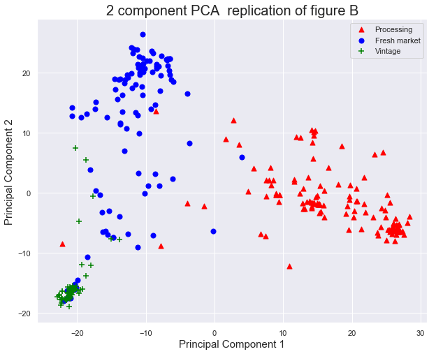

```python
sns.set()


f, ax = plt.subplots(1, 1, figsize=(10, 8))
ax.set_xlabel('Principal Component 1', fontsize = 15)
ax.set_ylabel('Principal Component 2', fontsize = 15)
ax.set_title('2 component PCA  replication of figure B', fontsize = 20)
for t in type_to_col:
    tmp_df = finalDf_b[finalDf_b['Specimen Type']==t]
    if tmp_df.shape[0] > 0:
        ax.scatter(tmp_df['principal component 1']
               , tmp_df['principal component 2']
               , s = 50,c=type_to_col[t],marker=type_to_marker[t],label=t)

ax.legend()

plt.show()
```

```python
for i,var in enumerate(pca_b.explained_variance_):
    print("Variance in Principal Component {}: {}".format(i+1,var))
```

```
Variance in Principal Component 1: 326.169108809
Variance in Principal Component 2: 161.314444449
```

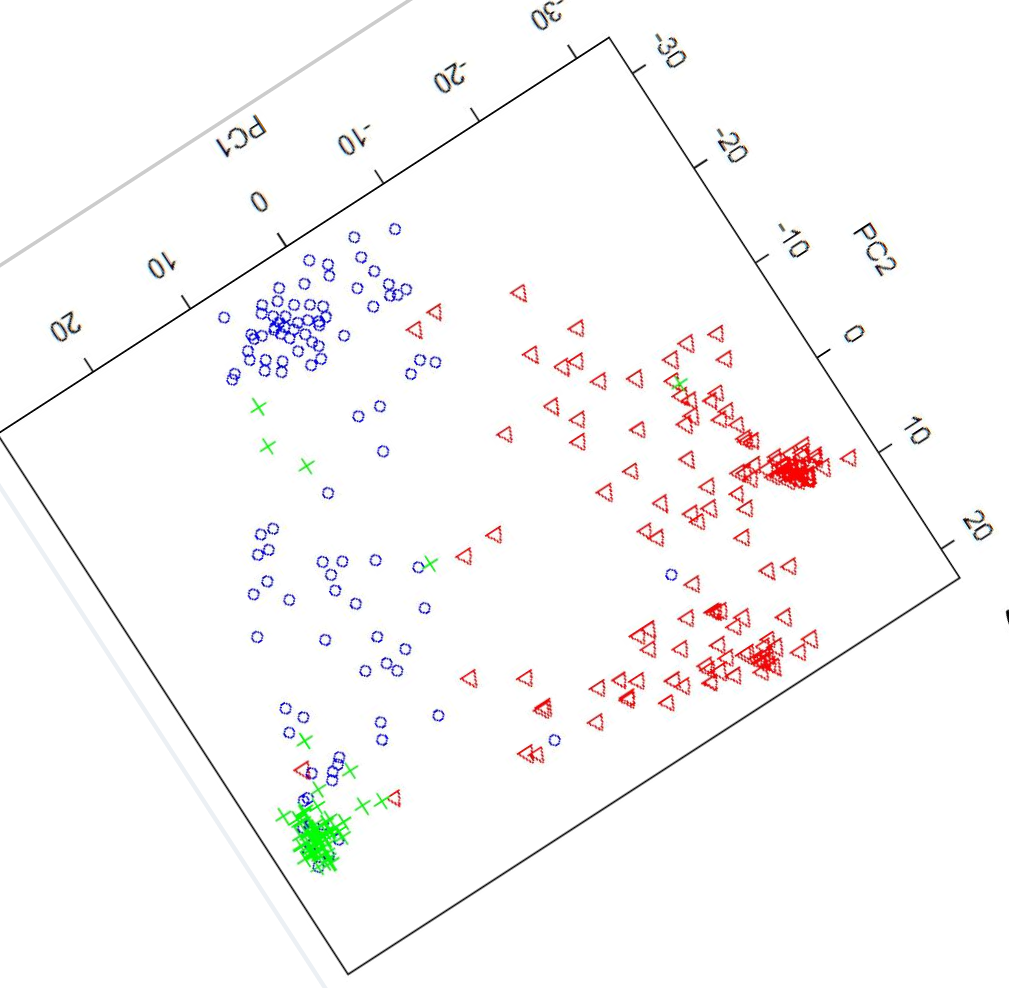

```python
Image("./imgs/Figure1B_rot.png")
```

Overall I'm pretty pleased with this graph as the claims that the paper was making I can replicate to some extent using their data. It seems that compared to figure 1A I am getting a similar quality of result, so again I believe that this is occuring due to a difference in preprocessing technique or library?

It's definately not identical to the results produced by the paper, but they are pretty close and I can arrive at the same conclusions as the writers of the paper did so I think the writers did a pretty good job at ensuring the quality and reproducibility of their work.

## why the PCA is important & what it shows

The PCA is important as it allows us to make sense of the vast amount of genomic data that each organism contains and find connections between the genome of organisms in a common species to further understanding the genome of that specific species and identify regions of interest within the species' genome which have phenotypic significance. To put the amount of data that the PCA is able to sift through in a matter of minutes, this SNP table was 400+ organisms with 7000+ dimensions of information which needed to be condensed to 2 dimensions to even visualize. A person cannot begin to fathom processing such data by hand, nor without linear algebra would they know where to start. The PCA is able to sift through this data without much maintenance after processing the data making it a form of unsupervised learning model. This means that it uses the natural distribution of the data for classification and doesn't require any labeled data. For example the subpopulations of the tomatoes need not be labeled for the pca to produce a similar looking plot to the plots above (just without the colors) saving time and resources in other & future applications. Overall the PCA is important as it provides a way to interpret this vast amount of genomic and SNP data regarding the species under study.

## why I chose this paper

The primary motives for pursuing this project were to learn more about the vast and wonderful world of Bioinformatics & complete the course objectives so I can pass this course.

But out of all the papers why one about SNP's in Tomatoes?

Well short story ... Google loaded this paper 1st.

Long story ... My Instructor, Edwin, recomended if we get stuck finding papers we just look up "Rice PCA China" and we will find mountains of papers that we can use. He was right, but I was stubborn. I didn't want to do what everyone else was doing, so I began looking up a whole bunch of different organisms trying to find a good PCA study. Now I knew about PCA all the way from linear algebra and I knew that its true power lay in reducing the dimensions of extremely large datasets to uncover relations and correlations that could not be gleaned by the naked eye or the efforts of a person. When I found papers with tiny datasets (50x20) I looked further for a paper that understood the technique and applied it appropriately and for a problem that needed it. A little while later I looked up "Tomato PCA" and found a really good paper in Nature that included a bunch of data and its processing scripts. I didn't know what SNP was or what most of the words in the paper meant, but I grabbed a table whose rows matched the rows of the resultant PCA & started my analysis hoping to be done with the project fairly quickly. After the PCA was done I knew that I did something horribly wrong as the result I was getting wasn't even close to the results from the paper. I actually needed to understand what they were doing and what was going on. So I go ask Edwin & he confirms my suspicions that I was doing this all wrong. He explains the basics of what SNP's were and how what I thought was the dataset was clearly not the dataset they were referencing. I began looking into the paper and scripts further and I realized that they were doing all the analysis on a different dataset that I didn't have access to that the paper referenced from a different paper (this paper). Looking up that paper I found the SNP dataset, but it was a different format that Edwin had mentioned. At this point I was highly debating if I wanted to enter this rabbit hole or should I just chose a different paper with a smaller dataset & take the easy way out. But that isn't me, I don't run away from problems. I choose to spend too many hours and too much energy overcoming and surpassing adversity. I went through like 3 Bio textbooks (no joke) trying to figure out what format the SNP data was in and how to properly interpret it, what exactly was going on in the paper, and processing the data like the paper with the appropriate filter methods. At this point I was consumed by the challenge of being able to learn something new all by myself & simply repeat what these scientists had done 6 years ago on my laptop.

I initially chose a tomato paper due to my Hubris, but I stuck with it and eventually did my report on this one due to my pride. If I can't pick up things left & right what type of programmer am I, and how do I expect to stay in Bioinformatics?

## data disclaimer & please no sue

I do not own any of the data I used nor any of the analysis that the paper concluded.

The paper can be found online at: https://www.ncbi.nlm.nih.gov/pmc/articles/PMC3447764/  
The datasets and tables can be found under Supplementary Materials.

Sung-Chur Sim or any of the other authors, if you are reading this please don't pursue legal action against me. I am poor college student. :( I mean no harm. I just want to learn. :D